# Reproductible Research - Week 2 - Assignement 1

Purpose of the report: Coursera course Assignment“.

## Downloading, unziping and loading data

1. Load the data (i.e. read.csv())
2. Process/transform the data (if necessary) into a format suitable for your analysis

```r
if(!file.exists("repdata_data_activity.zip")) {
        download.file("https://d396qusza40orc.cloudfront.net/repdata%2Fdata%2Factivity.zip","repdata_data_activity.zip")
        unzip("repdata_data_activity.zip")
}
db <- read.csv("activity.csv")
```

## What is mean total number of steps taken per day? For this part of the assignment, you can ignore the missing values in the dataset.

1. Calculate the total number of steps taken per day
2. If you do not understand the difference between a histogram and a barplot, research the difference between them. Make a histogram of the total number of steps taken each day
3. Calculate and report the mean and median of the total number of steps taken per day

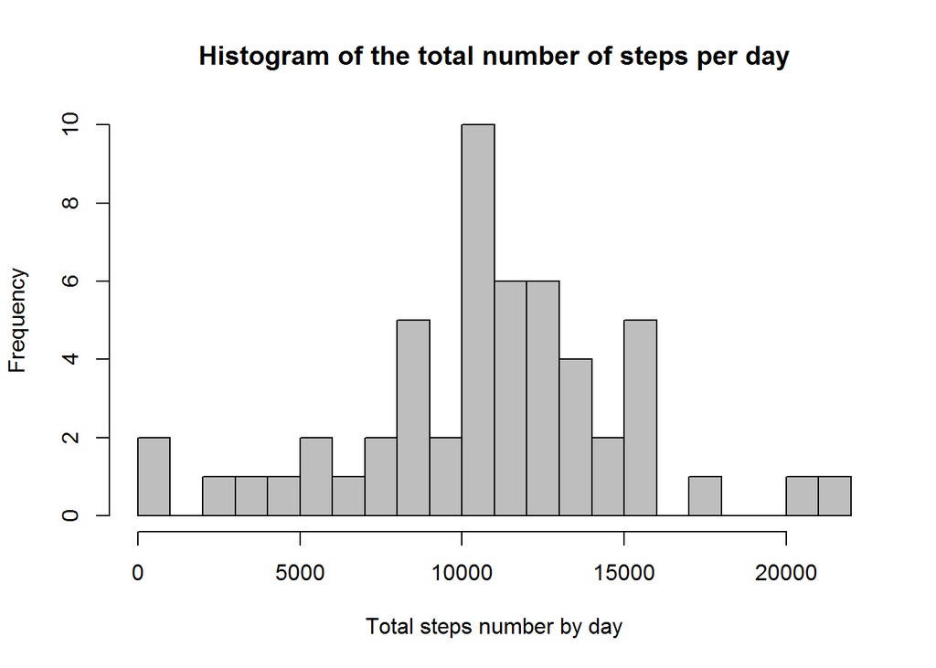

```r
TotNumSteps <- aggregate(steps~date, data=db, FUN=sum, na.rm=TRUE)
hist(TotNumSteps$steps, breaks=20, col='gray', main="Histogram of the total number of steps per day", xlab="Total steps number by day")
```

Mean and Median:

```r
MeanSteps<-mean(TotNumSteps$steps, na.rm=TRUE)
MeanSteps
```

```
## [1] 10766.19
```

```r
MedianSteps<-median(TotNumSteps$steps, na.rm=TRUE)
MedianSteps
```

```
## [1] 10765
```

## What is the average daily activity pattern?

1. Make a time series plot (i.e. type = “l”) of the 5-minute interval (x-axis) and the average number of steps taken, averaged across all days (y-axis)

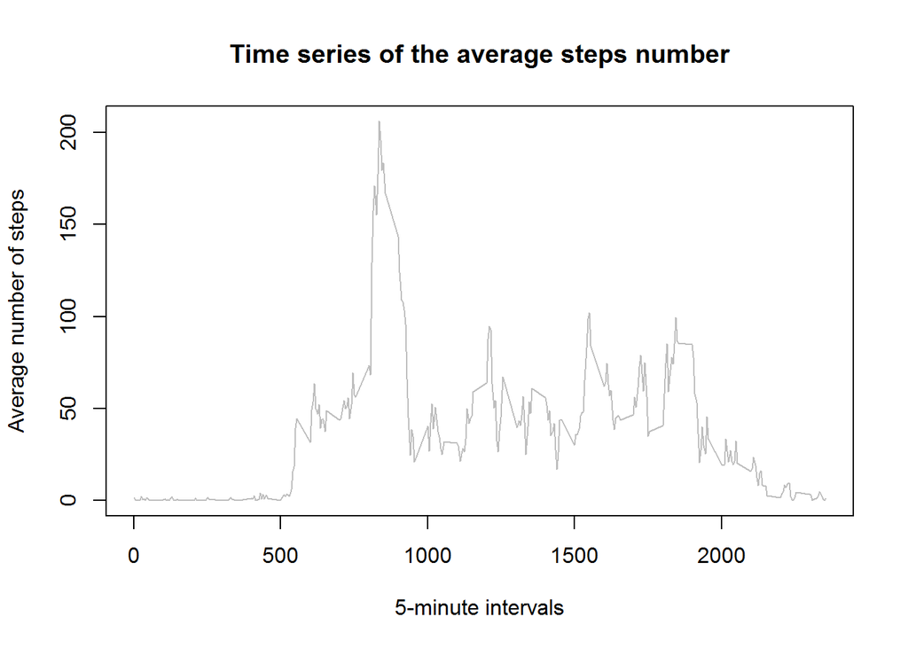

```r
AvgSteps <- aggregate(steps~interval, data=db, FUN=mean, na.rm=TRUE)
plot(AvgSteps, type="l", col='gray', main="Time series of the average steps number", xlab="5-minute intervals", ylab="Average number of steps")
```

2. Which 5-minute interval, on average across all the days in the dataset, contains the maximum number of steps?

The following interval contains the maximum number of steps.

```r
AvgSteps[which.max(AvgSteps$steps),1]
```

```
## [1] 835
```

```r
AvgSteps[which.max(AvgSteps$steps)+1,1]
```

```
## [1] 840
```